# Northern Great Plains Site Selection Report

Nate Ingelfinger & Ethan Linck, Montana State University

Britt Heidinger, North Dakota State University

2025-05-21

To propose sites to resurvey in the Northern Great Plains, we decided to visualize species richness and number of records across our region using geospatial tools in R. We begin by loading a number of libraries for our analysis:

```r
library(tidyverse)
library(ggplot2) # load ggplot graphics library
library(sf) # load Rspatial package
library(maps) # load "maps" package
library(elevatr) # load "elevatr" package
library(terra) # load "terra" package
library(ggrepel)
data <- read_csv("data/occurences.csv")
```

To aid in site selection, a subset of the occurrence data was created by filtering records collected before 1950 from the states of Montana, North Dakota, and South Dakota. The data set was further refined to retain only the relevant fields: taxonomic class, species, state or province, locality, and year of collection. Note that we need to filter by nonstandard naming in the original data:

```r
# look at variable spellings of state names
data$stateProvi %>% unique() %>% sort()
```

```
##  [1] "[North Dakota]"               "Alberta"
##  [3] "Alberta (Prov.)"              "Alberta prov"
##  [5] "Alberta/Saskatchewan"         "Chihuahua"
##  [7] "Co"                           "Coahuila"
##  [9] "Coahuila de zaragoza"         "Coahuila de Zaragoza (State)"
## [11] "Colorado"                     "Colorado (State)"
## [13] "Dakota"                       "Iowa"
## [15] "Iowa (State)"                 "Kansas"
## [17] "Kansas (State)"               "Ks"
## [19] "La"                           "Louisiana"
## [21] "Louisiana (State)"            "Manitoba"
## [23] "Manitoba ?"                   "Manitoba (Prov.)"
## [25] "Mb"                           "Minnesota"
## [27] "Minnesota (State)"            "Missouri"
## [29] "Mn"                           "Mo"
```

[output cut: 18 more lines]

```r
states_verbatim <- c("[North Dakota]", "Nd", "North dakota", "North Dakota",
                     "North Dakota (State)", "Sd", "South dakota", "South Dakota",
                     "Montana (State)", "Montana")

#subset columns we are interested in:
subset_data <- data %>%
  select(class, locality, species, stateProvi, decimalLat, decimalLon, year, institutio) %>%
  filter(stateProvi %in% c("Montana", "North Dakota", "South Dakota")) %>%
  mutate(state_clean = case_when(
    str_to_lower(stateProvi) %in% c("nd", "[north dakota]", "north dakota (state)", "north dakota") ~ "North Dakota",
    str_to_lower(stateProvi) %in% c("sd", "south dakota") ~ "South Dakota",
    str_to_lower(stateProvi) %in% c("montana", "montana (state)") ~ "Montana",
    TRUE ~ locality
  ))

#count the number of observations in each taxonomic class
subset_data %>%
  group_by(class, state_clean) %>%
  summarise(n = n())
```

```
## # A tibble: 15 × 3
## # Groups:   class [5]
##    class      state_clean      n
##    <chr>      <chr>        <int>
##  1 Amphibia   Montana         45
##  2 Amphibia   North Dakota    12
##  3 Amphibia   South Dakota    17
##  4 Aves       Montana        156
##  5 Aves       North Dakota  3941
##  6 Aves       South Dakota   218
##  7 Mammalia   Montana        525
##  8 Mammalia   North Dakota   279
##  9 Mammalia   South Dakota   479
## 10 Squamata   Montana        200
## 11 Squamata   North Dakota    80
## 12 Squamata   South Dakota   961
## 13 Testudines Montana         15
## 14 Testudines North Dakota    16
## 15 Testudines South Dakota    15
```

```r
#count the number of observations in each taxonomic class
subset_data %>%
  group_by(class, state_clean) %>%
  summarise(n = n_distinct(species))
```

```
## # A tibble: 15 × 3
## # Groups:   class [5]
##    class      state_clean      n
##    <chr>      <chr>        <int>
##  1 Amphibia   Montana          6
##  2 Amphibia   North Dakota     4
##  3 Amphibia   South Dakota     3
##  4 Aves       Montana         46
##  5 Aves       North Dakota   233
##  6 Aves       South Dakota    76
##  7 Mammalia   Montana         53
##  8 Mammalia   North Dakota    21
##  9 Mammalia   South Dakota    39
## 10 Squamata   Montana         13
## 11 Squamata   North Dakota    10
## 12 Squamata   South Dakota    24
## 13 Testudines Montana          3
## 14 Testudines North Dakota     2
## 15 Testudines South Dakota     3
```

Next, we’ll geberate a histogram to illustrate the distribution of collection years for all samples in the data set. This visualization provides insight into the patterns of sampling effort and helps identify periods of peak collection activity.

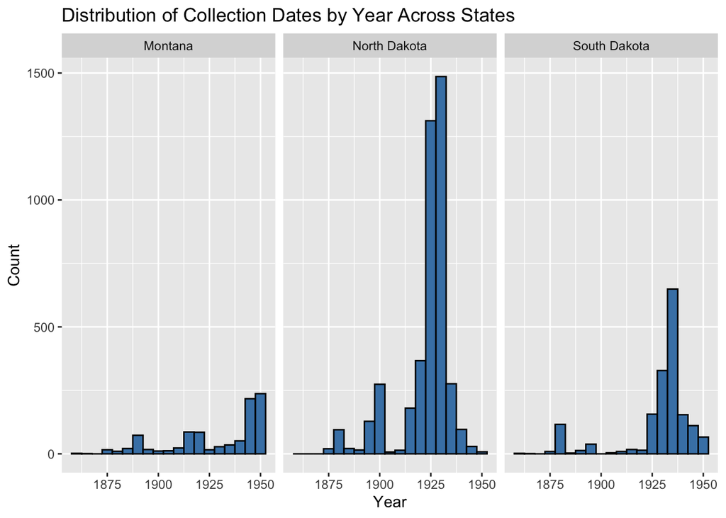

```r
ggplot(subset_data, aes(x = year)) +
  geom_histogram(binwidth = 5, fill = "steelblue", color = "black") +
  labs(
    title = "Distribution of Collection Dates by Year Across States",
    x = "Year",
    y = "Count"
  ) +
  facet_wrap(~state_clean)
```

We now want to prepare spatial data for mapping the species occurrence records in Montana, North Dakota, and South Dakota. This code will also check that the projections are consistent and filters the data set to the area of interest.

```r
# set map projections
map_proj <- st_crs("EPSG:4326")

# get state and county shapefiles
states <- st_as_sf(maps::map("state", plot = FALSE, fill = TRUE), crs = map_proj)

# filter state and county shapefiles for Montana, North Dakota, South Dakota
MT_ND_SD_states <- states[states$ID %in% c("montana", "north dakota", "south dakota"),]
counties <- st_as_sf(maps::map("county", plot = FALSE, fill = TRUE), crs = map_proj)
MT_ND_SD_counties <- subset(counties, grepl("montana|north dakota|south dakota", counties$ID))

# transform CRS
MT_ND_SD_states <- st_transform(MT_ND_SD_states, crs = map_proj)
MT_ND_SD_counties <- st_transform(MT_ND_SD_counties, crs = map_proj)
```

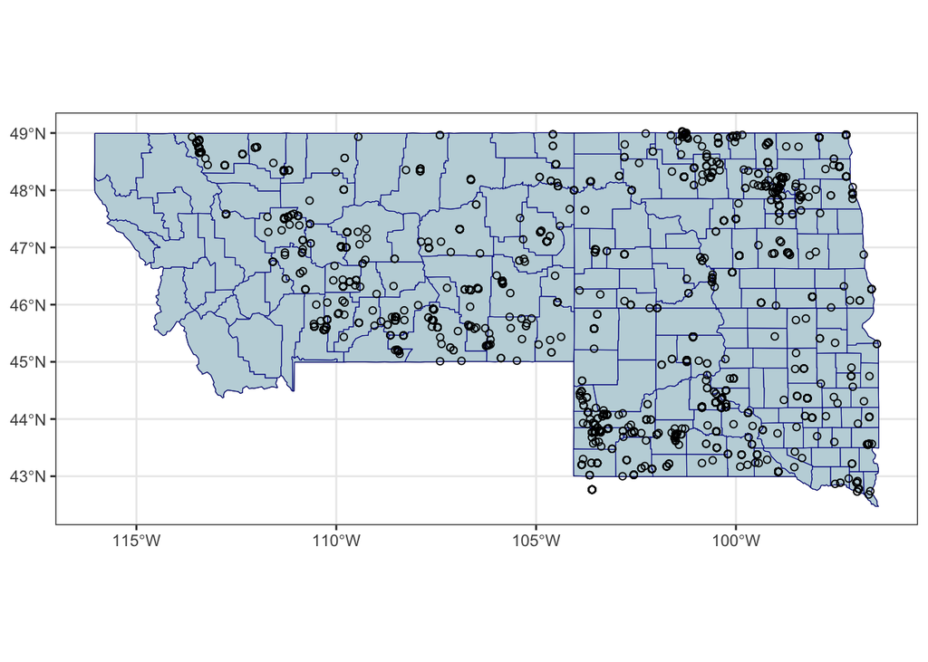

```r
# turn subset data into points
points_sf <- st_as_sf(subset_data, coords = c("decimalLon", "decimalLat"), crs = map_proj)

# Define bounding box for Montana, North Dakota, and South Dakota due to an outlying point
bbox <- st_sfc(st_polygon(list(matrix(c(-115, 40,   # Longitudes and latitudes for the bounding box
                                        -85, 40,
                                        -85, 50,
                                        -115, 50,
                                        -115, 40),
                                      ncol = 2, byrow = TRUE))),
               crs = map_proj)

# Filter out points outside the bounding box
points_sf_filtered <- points_sf[st_intersects(points_sf, bbox, sparse = FALSE), ]

# Simple ggplot of Montana, North Dakota, and South Dakota with filtered points
ggplot() +
  theme_bw() +
  geom_sf(data = MT_ND_SD_states, fill = "lightgray", color = "black") +  # States
  geom_sf(data = MT_ND_SD_counties, fill = "lightblue", color = "darkblue", alpha=0.5) +  # Counties (optional)
  geom_sf(data = points_sf_filtered, pch = 1) +  # Add filtered points
  theme(axis.title = element_blank()) +
  coord_sf()  # Automatically crops to the boundaries of the selected states
```

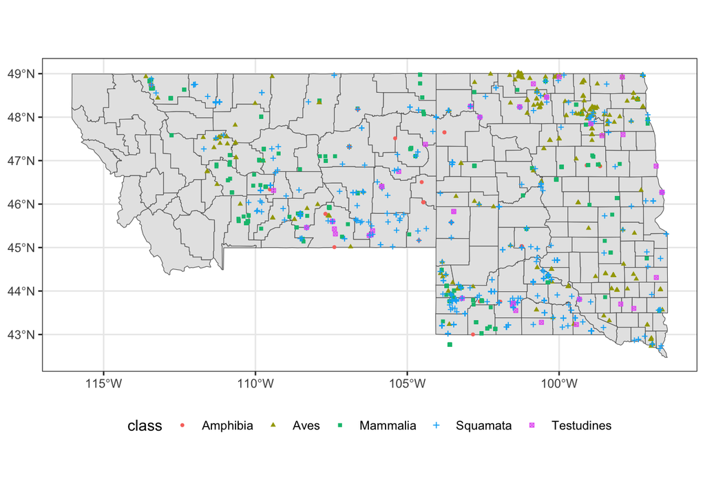

```r
# Filter out points outside the bounding box for Montana, North Dakota, and South Dakota
points_sf_filtered <- points_sf[st_intersects(points_sf, bbox, sparse = FALSE), ]

# Separate out the map by class and focus on the three states, showing only filtered points
ggplot(data = MT_ND_SD_counties) +
  theme_bw() +
  geom_sf() +  # Plot counties
  geom_sf(data = points_sf_filtered, aes(shape = class, color = class), size = 1) +  # Map shape and color to class
  theme(
    axis.title = element_blank(),
    legend.position = "bottom"
    ) +
  coord_sf()
```

Next, we’ll build on the previous visualization by incorporating Eco-regions as the base layer. By overlaying species occurrence records onto ecological regions, this map aids in refining site selection by highlighting records located within areas characteristic of the Great Plains.

```r
# Load ecoregion shapefiles for Montana, North Dakota, and South Dakota
mt_shp <- st_read("data/mt_eco_l4/mt_eco_l4.shp")  # Montana ecoregions
nd_shp <- st_read("data/nd_eco_l4/nd_eco_l4.shp")  # North Dakota ecoregions
sd_shp <- st_read("data/sd_eco_l4/sd_eco_l4.shp")  # South Dakota ecoregions
```

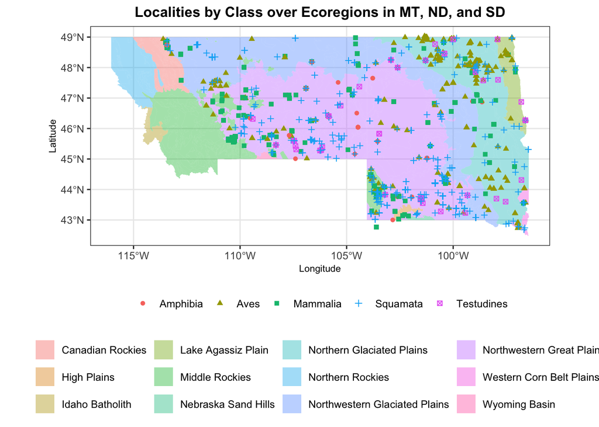

```r
# Transform shapefiles to the same CRS
mt_shp_transf <- st_transform(mt_shp, crs = map_proj)
nd_shp_transf <- st_transform(nd_shp, crs = map_proj)
sd_shp_transf <- st_transform(sd_shp, crs = map_proj)

# subset down to same number of columns
mt_shp_transf <- mt_shp_transf %>% select(!OBJECTID)
sd_shp_transf <- sd_shp_transf %>% select(!OBJECTID)

# combined shp file
combined_shp <- rbind(mt_shp_transf, nd_shp_transf, sd_shp_transf)

# Base plot without legends
ggplot() +
  theme_bw() +
  geom_sf(data = combined_shp, aes(fill = US_L3NAME), alpha = 0.4, color = NA,) +
  geom_sf(data = points_sf_filtered, aes(shape = class, color = class), size = 1.5) +
  labs(
    title = "Localities by Class over Ecoregions in MT, ND, and SD",
    x = "Longitude", y = "Latitude"
  ) +
  theme(
    plot.title = element_text(hjust = 0.5, size = 12, face = "bold"),
    axis.title = element_text(size = 8),
    legend.position = "bottom",
    legend.title = element_blank()
  ) +
  theme(
    legend.position = "bottom",     # Place the whole legend area at the bottom
    legend.box = "vertical"         # Stack individual legends vertically
  ) +
  guides(
    fill = guide_legend(title = "Category", direction = "horizontal"),
    shape = guide_legend(title = "Type", direction = "horizontal"),
    color = guide_legend(title = "Type", direction = "horizontal")

  ) +
  coord_sf()
```

The following six maps display a hexagonal heatmap of species richness and total number of occurences overlaid with points, color-coded by taxonomic class. These visualizations facilitate the identification of areas with higher species richness and collecting effort while also indicating which taxonomic groups were collected at each location.

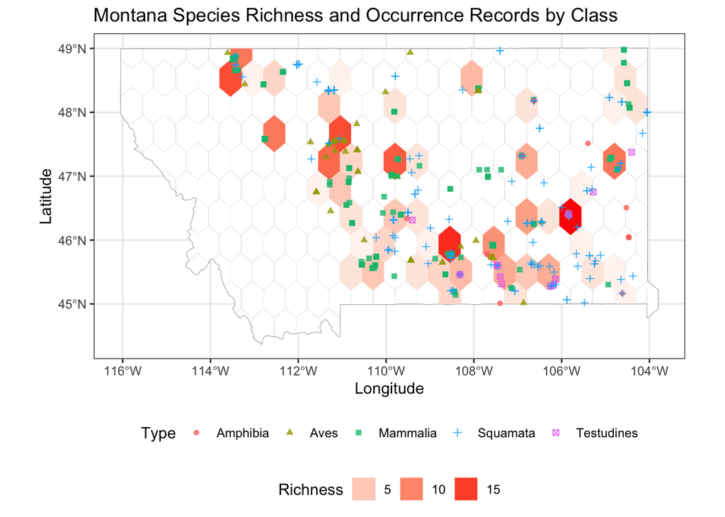

```r
# Make sure geometries are valid
MT_ND_SD_states_valid <- st_make_valid(MT_ND_SD_states)

# Create the grid
MT_ND_SD_grid <- MT_ND_SD_states_valid %>%
  # for hexagonal cells the distance between opposite edges (edge length is cellsize/sqrt(3)).
  st_make_grid(cellsize = .5, square = FALSE) %>%
  st_intersection(MT_ND_SD_states_valid) %>%
  st_sf()

# Order grid cells from southwest to northeast
MT_ND_SD_grid <- MT_ND_SD_grid %>%
  mutate(centroid = st_centroid(geometry)) %>%
  mutate(x = st_coordinates(centroid)[,1],
         y = st_coordinates(centroid)[,2]) %>%
  arrange(y, x) %>%
  mutate(cellid = row_number()) %>%
  select(-centroid, -x, -y)

# check geometry
MT_ND_SD_grid <- st_transform(MT_ND_SD_grid, crs = map_proj)

# Filter Montana state
MT_state <- MT_ND_SD_states %>% filter(ID == "montana")

# Filter species points to just Montana
points_mt <- points_sf_filtered[st_intersects(points_sf_filtered, MT_state, sparse = FALSE), ]

# Filter grid cells that intersect with Montana
MT_grid <- MT_ND_SD_grid[st_intersects(MT_ND_SD_grid, MT_state, sparse = FALSE), ]

# Calculate species richness per grid cell in Montana
richness_grid_mt <- MT_grid %>%
  st_join(points_mt) %>%
  distinct(cellid, species, geometry) %>%               # Keep only one row per species per cell
  group_by(cellid) %>%
  summarize(num_species = n(), .groups = "drop", do_union = FALSE) %>%            # Count unique species per cell
  mutate(log_num_species = log(num_species + 1))

# calculate collecting effort (# of specimens)
effort_grid_mt <- MT_grid %>%
  st_join(points_mt) %>%
  mutate(overlap = ifelse(!is.na(id), 1, 0)) %>%
  group_by(cellid) %>%
  summarize(n = n())

ggplot() +
  # Base species richness grid
  geom_sf(data = MT_grid, fill = NA, size = 0.1) +
  geom_sf(data = richness_grid_mt, aes(fill = num_species), color = NA) +
  # Change color scale to white -> red
  scale_fill_gradient(
    low = "white",
    high = "red",
    na.value = "transparent",
    name = "Species Richness"
  ) +
  # Overlay occurrence points by class
  geom_sf(data = points_mt, aes(shape = class, color = class), size = 1.5, alpha = 0.8) +
  # Labels and theming
  labs(color = "Class", shape = "Class") +
  xlab("Longitude") +
  ylab("Latitude") +
  theme_bw() +
  theme(
    legend.position = "bottom",     # Place the whole legend area at the bottom
    legend.box = "vertical"         # Stack individual legends vertically
  ) +
  guides(
    fill = guide_legend(title = "Richness", direction = "horizontal"),
    shape = guide_legend(title = "Type", direction = "horizontal"),
    color = guide_legend(title = "Type", direction = "horizontal"),
  ) +    ggtitle("Montana Species Richness and Occurrence Records by Class")
```

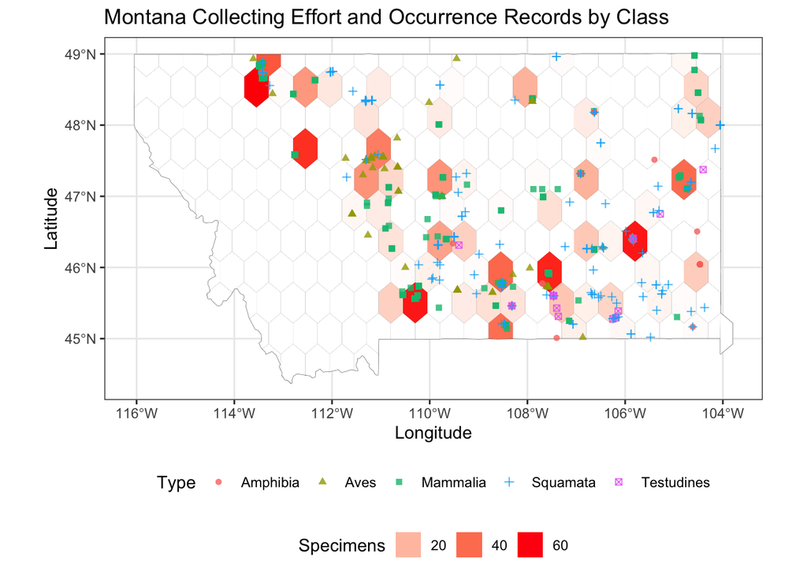

```r
ggplot() +
  geom_sf(data = MT_grid, fill = NA, size = 0.1) +
  geom_sf(data = effort_grid_mt, aes(fill = n), color = NA) +
  # Change color scale to white -> red
  scale_fill_gradient(
    low = "white",
    high = "red",
    na.value = "transparent",
    name = "Collecting Effort (n)"
  ) +
  # Overlay occurrence points by class
  geom_sf(data = points_mt, aes(shape = class, color = class), size = 1.5, alpha = 0.8) +
  # Labels and theming
  labs(color = "Class", shape = "Class") +
  xlab("Longitude") +
  ylab("Latitude") +
  theme_bw() +
  theme(
    legend.position = "bottom",     # Place the whole legend area at the bottom
    legend.box = "vertical"         # Stack individual legends vertically
  ) +
  guides(
    fill = guide_legend(title = "Specimens", direction = "horizontal"),
    shape = guide_legend(title = "Type", direction = "horizontal"),
    color = guide_legend(title = "Type", direction = "horizontal"),
  ) +
  ggtitle("Montana Collecting Effort and Occurrence Records by Class")
```

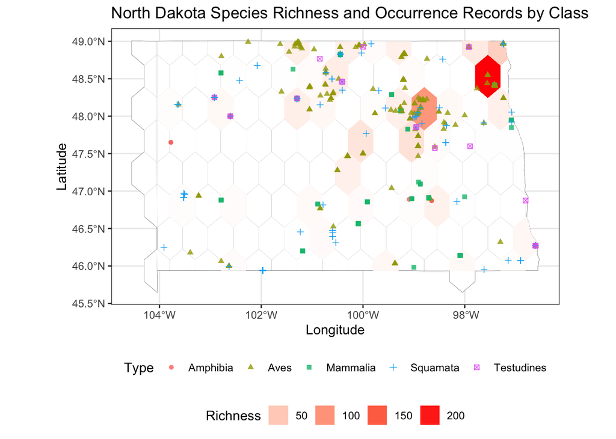

```r
# Filter North Dakota state
ND_state <- MT_ND_SD_states %>% filter(ID == "north dakota")

# Filter species points to just North Dakota
points_nd <- points_sf_filtered[st_intersects(points_sf_filtered, ND_state, sparse = FALSE), ]

# Filter grid cells that intersect with North Dakota
ND_grid <- MT_ND_SD_grid[st_intersects(MT_ND_SD_grid, ND_state, sparse = FALSE), ]

# Calculate species richness per grid cell in Montana
richness_grid_nd <- ND_grid %>%
  st_join(points_nd) %>%
  distinct(cellid, species, geometry) %>%               # Keep only one row per species per cell
  group_by(cellid) %>%
  summarize(num_species = n(), .groups = "drop", do_union = FALSE) %>%            # Count unique species per cell
  mutate(log_num_species = log(num_species + 1))

# calculate collecting effort (# of specimens)
effort_grid_nd <- ND_grid %>%
  st_join(points_nd) %>%
  mutate(overlap = ifelse(!is.na(id), 1, 0)) %>%
  group_by(cellid) %>%
  summarize(n = n())

ggplot() +
  # Base species richness grid
  geom_sf(data = ND_grid, fill = NA, size = 0.1) +
  geom_sf(data = richness_grid_nd, aes(fill = num_species), color = NA) +
  # Change color scale to white -> red
  scale_fill_gradient(
    low = "white",
    high = "red",
    na.value = "transparent",
    name = "Species Richness"
  ) +
  # Overlay occurrence points by class
  geom_sf(data = points_nd, aes(shape = class, color = class), size = 1.5, alpha = 0.8) +
  # Labels and theming
  labs(color = "Class", shape = "Class") +
  xlab("Longitude") +
  ylab("Latitude") +
  theme_bw() +
  theme(
    legend.position = "bottom",     # Place the whole legend area at the bottom
    legend.box = "vertical"         # Stack individual legends vertically
  ) +
  guides(
    fill = guide_legend(title = "Richness", direction = "horizontal"),
    shape = guide_legend(title = "Type", direction = "horizontal"),
    color = guide_legend(title = "Type", direction = "horizontal"),
  ) +
  ggtitle("North Dakota Species Richness and Occurrence Records by Class")
```

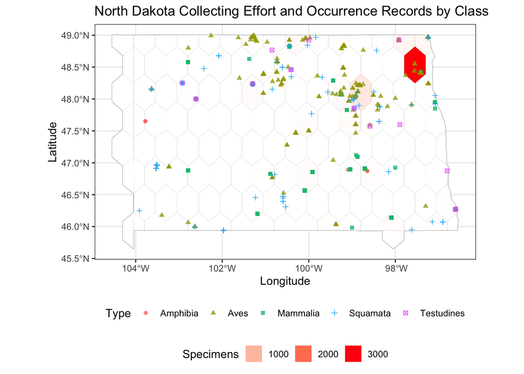

```r
ggplot() +
  geom_sf(data = ND_grid, fill = NA, size = 0.1) +
  geom_sf(data = effort_grid_nd, aes(fill = n), color = NA) +
  # Change color scale to white -> red
  scale_fill_gradient(
    low = "white",
    high = "red",
    na.value = "transparent",
    name = "Collecting Effort (n)"
  ) +
  # Overlay occurrence points by class
  geom_sf(data = points_nd, aes(shape = class, color = class), size = 1.5, alpha = 0.8) +
  # Labels and theming
  labs(color = "Class", shape = "Class") +
  xlab("Longitude") +
  ylab("Latitude") +
  theme_bw() +
  theme(
    legend.position = "bottom",     # Place the whole legend area at the bottom
    legend.box = "vertical"         # Stack individual legends vertically
  ) +
  guides(
    fill = guide_legend(title = "Specimens", direction = "horizontal"),
    shape = guide_legend(title = "Type", direction = "horizontal"),
    color = guide_legend(title = "Type", direction = "horizontal"),
  ) +
  ggtitle("North Dakota Collecting Effort and Occurrence Records by Class")
```

…and lastly, for South Dakota:

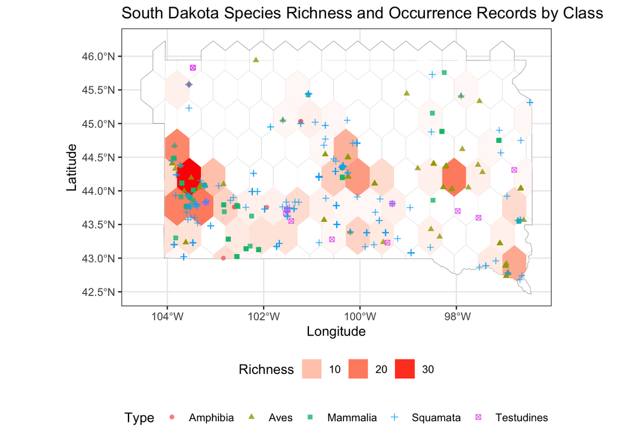

```r
# Filter South Dakota state
SD_state <- MT_ND_SD_states %>% filter(ID == "south dakota") %>% st_make_valid()

# Filter species points to just South Dakota
points_sd <- points_sf_filtered[st_intersects(points_sf_filtered, SD_state, sparse = FALSE), ] %>%
  st_make_valid()

# Filter grid cells that intersect with South Dakota
SD_grid <- MT_ND_SD_grid[st_intersects(MT_ND_SD_grid, SD_state, sparse = FALSE), ] %>%
  st_make_valid()

# Calculate species richness per grid cell in Montana
richness_grid_sd <- SD_grid %>%
  st_join(points_sd) %>%
  distinct(cellid, species, geometry) %>%               # Keep only one row per species per cell
  group_by(cellid) %>%
  summarize(num_species = n(), .groups = "drop", do_union = FALSE) %>%            # Count unique species per cell
  mutate(log_num_species = log(num_species + 1))

# calculate collecting effort (# of specimens)
effort_grid_sd <- SD_grid %>%
  st_join(points_sd) %>%
  mutate(overlap = ifelse(!is.na(id), 1, 0)) %>%
  group_by(cellid) %>%
  summarize(n = n())

ggplot() +
  # Base species richness grid
  geom_sf(data = SD_grid, fill = NA, size = 0.1) +
  geom_sf(data = richness_grid_sd, aes(fill = num_species), color = NA) +
  # Change color scale to white -> red
  scale_fill_gradient(
    low = "white",
    high = "red",
    na.value = "transparent",
    name = "Species Richness"
  ) +
  # Overlay occurrence points by class
  geom_sf(data = points_sd, aes(shape = class, color = class), size = 1.5, alpha = 0.8) +
  # Labels and theming
  labs(color = "Class", shape = "Class") +
  xlab("Longitude") +
  ylab("Latitude") +
  theme_bw() +
  theme(
    legend.position = "bottom",     # Place the whole legend area at the bottom
    legend.box = "vertical"         # Stack individual legends vertically
  ) +
  guides(
    fill = guide_legend(title = "Richness", direction = "horizontal"),
    shape = guide_legend(title = "Type", direction = "horizontal"),
    color = guide_legend(title = "Type", direction = "horizontal"),
  ) +
  ggtitle("South Dakota Species Richness and Occurrence Records by Class")
```

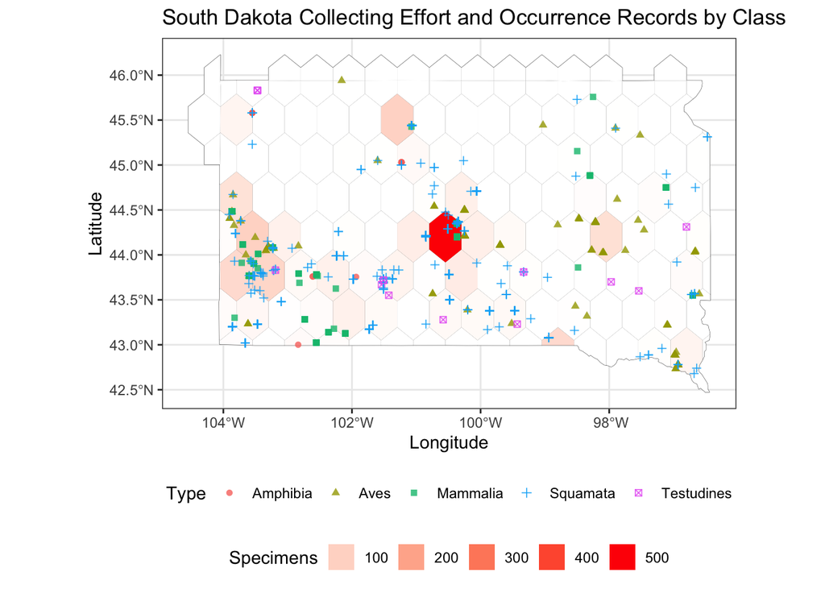

```r
ggplot() +
  geom_sf(data = SD_grid, fill = NA, size = 0.1) +
  geom_sf(data = effort_grid_sd, aes(fill = n), color = NA) +
  # Change color scale to white -> red
  scale_fill_gradient(
    low = "white",
    high = "red",
    na.value = "transparent",
    name = "Collecting Effort (n)"
  ) +
  # Overlay occurrence points by class
  geom_sf(data = points_sd, aes(shape = class, color = class), size = 1.5, alpha = 0.8) +
  # Labels and theming
  labs(color = "Class", shape = "Class") +
  xlab("Longitude") +
  ylab("Latitude") +
  theme_bw() +
  theme(
    legend.position = "bottom",     # Place the whole legend area at the bottom
    legend.box = "vertical"         # Stack individual legends vertically
  ) +
  guides(
    fill = guide_legend(title = "Specimens", direction = "horizontal"),
    shape = guide_legend(title = "Type", direction = "horizontal"),
    color = guide_legend(title = "Type", direction = "horizontal"),
  ) +
  ggtitle("South Dakota Collecting Effort and Occurrence Records by Class")
```

Let’s knock that out for the entire region:

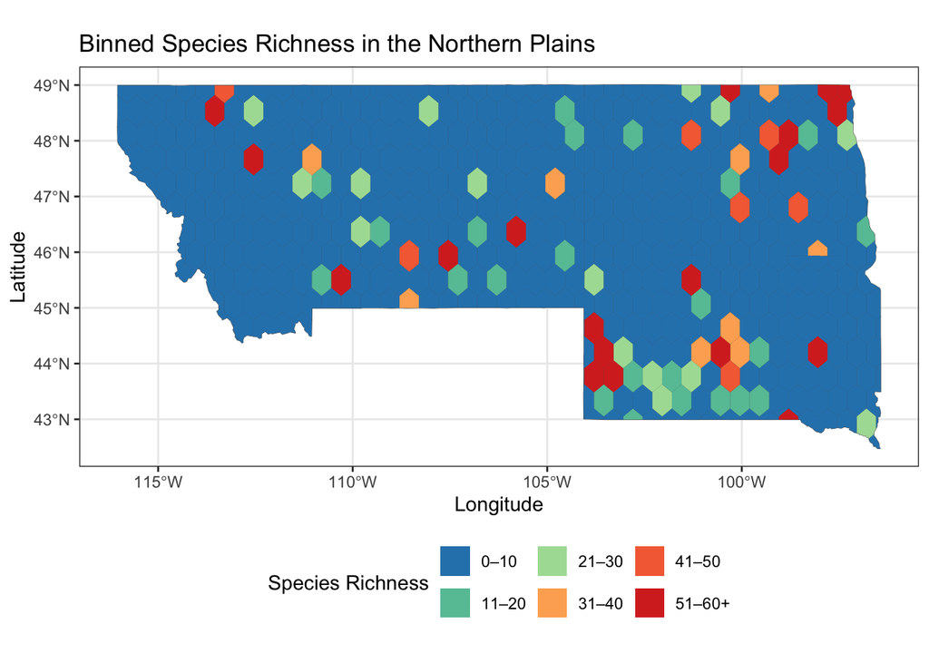

```r
# Make sure geometries are valid
MT_ND_SD_states_valid <- st_make_valid(MT_ND_SD_states)

# Create the grid with larger cellsize (0.2 instead of 0.1)
MT_ND_SD_grid <- MT_ND_SD_states_valid %>%
  st_make_grid(cellsize = 0.5, square=FALSE) %>%
  st_intersection(MT_ND_SD_states_valid) %>%
  st_make_valid() %>%
  st_sf()

# Order grid cells from southwest to northeast
MT_ND_SD_grid <- MT_ND_SD_grid %>%
  mutate(centroid = st_centroid(geometry)) %>%
  mutate(x = st_coordinates(centroid)[,1],
         y = st_coordinates(centroid)[,2]) %>%
  arrange(y, x) %>%
  mutate(cellid = row_number()) %>%
  select(-centroid, -x, -y)

# Transform CRS if needed
MT_ND_SD_grid <- st_transform(MT_ND_SD_grid, crs = map_proj)

# Recalculate capped richness and assign bins
richness_grid <- MT_ND_SD_grid %>%
  st_join(points_sf_filtered) %>%
  mutate(overlap = ifelse(!is.na(id), 1, 0)) %>%
  group_by(cellid) %>%
  summarize(num_species = sum(overlap)) %>%
  mutate(num_species_capped = ifelse(num_species > 60, 60, num_species),
         richness_bin = cut(num_species_capped,
                            breaks = c(-1, 10, 20, 30, 40, 50, 60),
                            labels = c("0–10", "11–20", "21–30", "31–40", "41–50", "51–60+")))

# Same thing for collecting effort:
effort_grid <- MT_ND_SD_grid %>%
  st_join(points_sf_filtered) %>%
  mutate(overlap = ifelse(!is.na(id), 1, 0)) %>%
  group_by(cellid) %>%
  summarize(n = n()) %>%
  mutate(records_capped = ifelse(n > 100, 100, n),
         records_bin = cut(records_capped,
                            breaks = c(-1, 20, 40, 60, 80, 100),
                            labels = c("0–20", "21–40", "41–60", "61–80", "81–100+")))

# Plot with 6-bin blue-to-yellow scale
ggplot(richness_grid) +
  geom_sf(data = MT_ND_SD_grid, fill = NA, size = 0.1) +
  geom_sf(aes(fill = richness_bin), color = NA) +
  labs(fill = "Species Richness") +
  scale_fill_manual(
    values = c(
      "0–10"    = "#2b83ba",  # blue
      "11–20"   = "#66c2a5",  # teal
      "21–30"   = "#abdda4",  # light green
      "31–40"   = "#fdae61",  # orange
      "41–50"   = "#f46d43",  # reddish-orange
      "51–60+"  = "#d73027"   # red-yellow
    ),
    drop = FALSE
  ) +
  xlab("Longitude") +
  ylab("Latitude") +
  theme_bw() +
  theme(legend.position = "bottom") +
  ggtitle("Binned Species Richness in the Northern Plains")
```

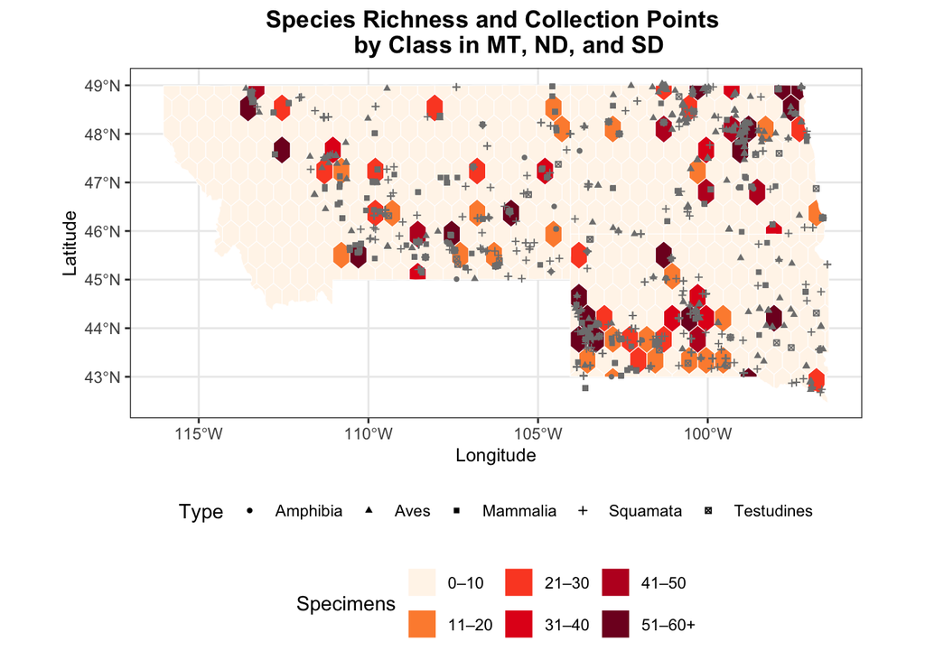

```r
# Define new red-orange color palette
richness_colors <- c(
  "0–10"    = "#fff5eb",
  "11–20"   = "#fd8d3c",
  "21–30"   = "#fc4e2a",
  "31–40"   = "#e31a1c",
  "41–50"   = "#bd0026",
  "51–60+"  = "#800026"
)

# Define new red-orange color palette
records_colors <- c(
  "0–20"    = "#fff5eb",
  "21–40"   = "#fd8d3c",
  "41–60"   = "#fc4e2a",
  "61–80"   = "#e31a1c",
  "81–100+"   = "#bd0026"
)

# Define clearer point colors (assuming 3 classes: A, B, C)
class_colors <- c(
  "A" = "#1f78b4",  # blue
  "B" = "#33a02c",  # green
  "C" = "#6a3d9a"   # purple
)

# Combined map plot
ggplot() +
  theme_bw() +

  # Basemap: Species richness bins
  geom_sf(data = richness_grid, aes(fill = richness_bin),
          color = "white", size = 0.05) +
  scale_fill_manual(
    values = richness_colors,
    drop = FALSE,
    name = "Species Richness",
  ) +

  # Overlay: Collection points
  geom_sf(
    data = points_sf_filtered,
    aes(shape = class, color = class),
    size = 1.1,
  ) +
  scale_color_manual(values = class_colors) +

  # Titles and labels
  labs(
    title = "Species Richness and Collection Points
    by Class in MT, ND, and SD",
    x = "Longitude",
    y = "Latitude",
    shape = "Class",
    color = "Class"
  ) +
  theme(
    plot.title = element_text(hjust = 0.5, size = 13, face = "bold"),
    axis.title = element_text(size = 10),
  ) +
  theme(
    legend.position = "bottom",     # Place the whole legend area at the bottom
    legend.box = "vertical"         # Stack individual legends vertically
  ) +
  guides(
    fill = guide_legend(title = "Specimens", direction = "horizontal"),
    shape = guide_legend(title = "Type", direction = "horizontal"),
    color = guide_legend(title = "Type", direction = "horizontal"),
  ) +
  coord_sf()
```

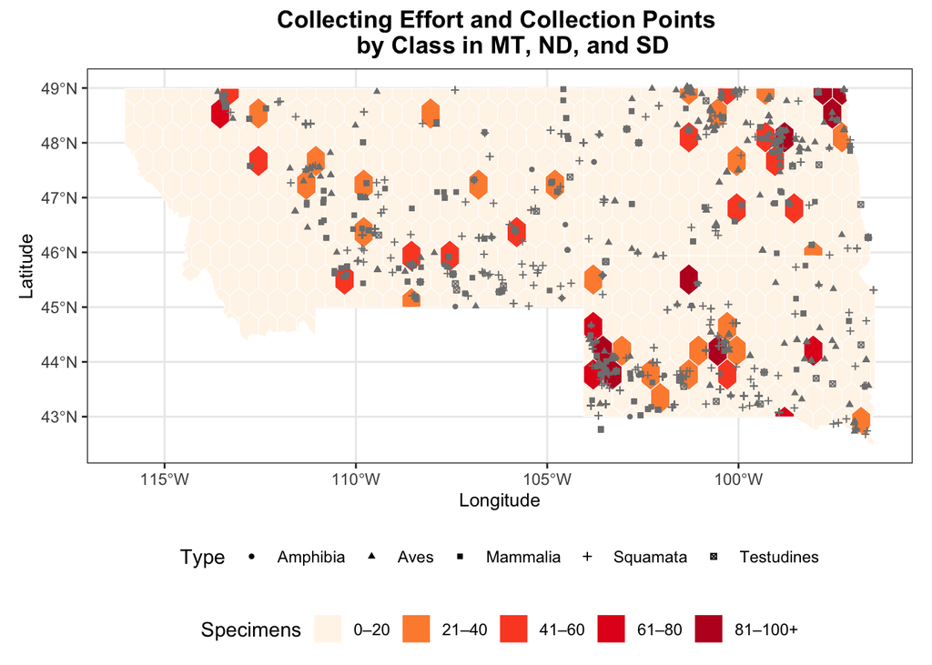

```r
# Same thing but for effort:
ggplot() +
  theme_bw() +

  # Basemap: Species richness bins
  geom_sf(data = effort_grid, aes(fill = records_bin),
          color = "white", size = 0.05) +
  scale_fill_manual(
    values = records_colors,
    drop = FALSE,
    name = "No. Specimens",
  ) +

  # Overlay: Collection points
  geom_sf(
    data = points_sf_filtered,
    aes(shape = class, color = class),
    size = 1.1,
  ) +
  scale_color_manual(values = class_colors) +

  # Titles and labels
  labs(
    title = "Collecting Effort and Collection Points
    by Class in MT, ND, and SD",
    x = "Longitude",
    y = "Latitude",
    shape = "Class",
    color = "Class"
  ) +
  theme(
    plot.title = element_text(hjust = 0.5, size = 13, face = "bold"),
    axis.title = element_text(size = 10),
  ) +
  theme(
    legend.position = "bottom",     # Place the whole legend area at the bottom
    legend.box = "vertical"         # Stack individual legends vertically
  ) +
  guides(
    fill = guide_legend(title = "Specimens", direction = "horizontal"),
    shape = guide_legend(title = "Type", direction = "horizontal"),
    color = guide_legend(title = "Type", direction = "horizontal"),
  ) +
  coord_sf()
```

Let’s plot the top site per taxon per state by species richness and collecting effort:

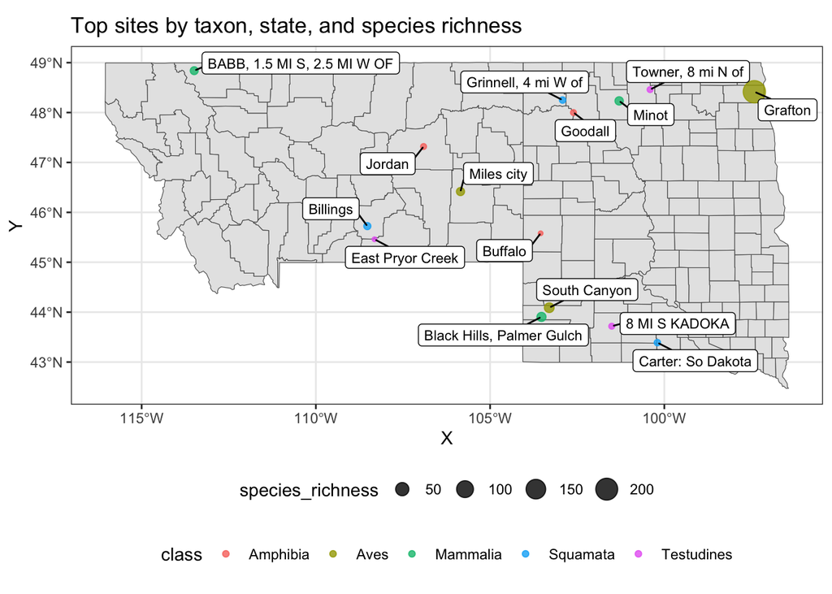

```r
# switch projection and simplify geometry to speed calculations
points_sf_filtered <- st_transform(points_sf_filtered, 3857) %>%
  st_simplify(dTolerance = 10)

# Buffer points by 1000 meters and dissolve overlapping ones to group nearby sites
grouped_sites <- points_sf_filtered %>%
  st_buffer(dist = 1000) %>%
  st_union() %>%
  st_sf(group_id = 1:length(.))

# Join original points to grouped polygons
joined <- st_join(points_sf_filtered, grouped_sites, join = st_intersects)

# calculate richness by merged localities, transform back
richness_by_group <- joined %>%
  group_by(state_clean, class, geometry, locality, institutio) %>%
  distinct(species) %>%
  summarise(species_richness = n(), .groups = "drop") %>% # count unique species per locality
  group_by(state_clean, class) %>%
  slice_max(species_richness, with_ties = FALSE) %>% # get most species-rich locality per class per state
  ungroup() %>%
  st_cast("POINT") %>%
  st_transform(map_proj)

# same thing but for effort!
effort_by_group <- joined %>%
  group_by(state_clean, class, geometry, locality, institutio) %>%
  summarise(n = n()) %>% # count number of records by locality
  group_by(state_clean, class) %>%
  slice_max(n, with_ties = FALSE) %>% # get most species-rich locality per class per state
  ungroup() %>%
  st_cast("POINT") %>%
  st_transform(map_proj)

# plot species richness
ggplot(data = MT_ND_SD_counties) +
  geom_sf() +
    geom_sf(data = richness_by_group,
          aes(color = class,
              size = species_richness),
          alpha = 0.8) +
  geom_label_repel(
    data =  richness_by_group %>%
      mutate(coords = st_coordinates(geometry)) %>%
      bind_cols(as_tibble(.$coords)),
    aes(x = X, y = Y, label = locality),
    size = 3,
    min.segment.length = 0,
    seed = 1234,
    max.overlaps = 100) +
  theme_bw() +
    labs(title = "Top sites by taxon, state, and species richness") +
   theme(
    legend.position = "bottom",     # Place the whole legend area at the bottom
    legend.box = "vertical"         # Stack individual legends vertically
  ) +
  guides(
    fill = guide_legend(title = "Category", direction = "vertical"),
    shape = guide_legend(title = "Type", direction = "vertical")
  )
```

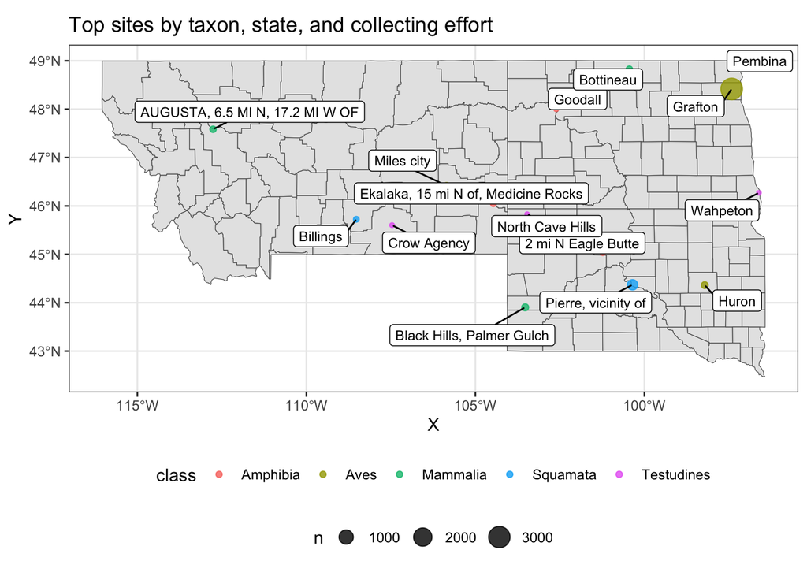

```r
# plot effort
ggplot(data = MT_ND_SD_counties) +
  geom_sf() +
    geom_sf(data = effort_by_group,
          aes(color = class,
              size = n),
          alpha = 0.8) +
  geom_label_repel(
    data =  effort_by_group %>%
      mutate(coords = st_coordinates(geometry)) %>%
      bind_cols(as_tibble(.$coords)),
    aes(x = X, y = Y, label = locality),
    size = 3,
    min.segment.length = 0,
    seed = 1234,
    max.overlaps = 100) +
  theme_bw() +
    labs(title = "Top sites by taxon, state, and collecting effort") +
  theme(
    legend.position = "bottom",     # Place the whole legend area at the bottom
    legend.box = "vertical"         # Stack individual legends vertically
  ) +
  guides(
    fill = guide_legend(title = "Category", direction = "vertical"),
    shape = guide_legend(title = "Type", direction = "vertical")
  )
```

Let’s print tables of an expanded version of this (top *2* sites per state per taxon):

```r
# calculate richness by merged localities, transform back
richness_by_group_2 <- joined %>%
  group_by(state_clean, class, geometry, locality, institutio) %>%
  distinct(species) %>%
  summarise(species_richness = n(), .groups = "drop") %>% # count unique species per locality
  group_by(state_clean, class) %>%
  top_n(2, species_richness) %>% # get most collection-rich localities per class per state
  ungroup() %>%
  st_cast("POINT") %>%
  st_transform(map_proj) %>%
  print(n=100)
```

```
## Simple feature collection with 73 features and 5 fields
## Geometry type: POINT
## Dimension:     XY
## Bounding box:  xmin: -113.4916 ymin: 43.00072 xmax: -96.60998 ymax: 48.92661
## Geodetic CRS:  WGS 84
## # A tibble: 73 × 6
##    state_clean  class      locality                  institutio species_richness
##  * <chr>        <chr>      <chr>                     <chr>                 <int>
##  1 Montana      Amphibia   Jordan                    UMMZ                      2
##  2 Montana      Amphibia   2 MI S MILES CITY         UMMZ                      2
##  3 Montana      Amphibia   St marys glacier nat park UMMZ                      2
##  4 Montana      Aves       Rainbow Falls             MCZ                       8
##  5 Montana      Aves       Miles city                UCLA                      9
##  6 Montana      Mammalia   AUGUSTA, 6.5 MI N, 17.2 … KU                        7
##  7 Montana      Mammalia   BABB, 1.5 MI S, 2.5 MI W… KU                        8
```

[output cut: 67 more lines]

```r
# same thing but for effort!
effort_by_group_2 <- joined %>%
  group_by(state_clean, class, geometry, locality, institutio) %>%
  summarise(n = n()) %>% # count number of records by locality
  group_by(state_clean, class) %>%
  top_n(2, n) %>% # get most collection-rich localities per class per state
  ungroup() %>%
  st_cast("POINT") %>%
  st_transform(map_proj) %>%
  print(n=100)
```

```
## Simple feature collection with 33 features and 5 fields
## Geometry type: POINT
## Dimension:     XY
## Bounding box:  xmin: -112.7616 ymin: 43.71801 xmax: -96.60998 ymax: 48.96539
## Geodetic CRS:  WGS 84
## # A tibble: 33 × 6
##    state_clean  class      locality   institutio     n             geometry
##  * <chr>        <chr>      <chr>      <chr>      <int>          <POINT [°]>
##  1 Montana      Amphibia   Ekalaka, … USNM          14   (-104.469 46.0431)
##  2 Montana      Amphibia   Jordan     UMMZ          10  (-106.909 47.31887)
##  3 Montana      Aves       Rainbow F… MCZ           14 (-111.1992 47.53833)
##  4 Montana      Aves       Miles city UCLA          43   (-105.85 46.41667)
##  5 Montana      Mammalia   CUSTER, 1… KU            40 (-107.5744 45.92644)
##  6 Montana      Mammalia   AUGUSTA, … KU            41  (-112.7616 47.5835)
##  7 Montana      Squamata   2 MI S HE… UMMZ          10 (-109.5029 46.43038)
```

[output cut: 26 more lines]

```r
richness_by_group_2
```

```
## Simple feature collection with 73 features and 5 fields
## Geometry type: POINT
## Dimension:     XY
## Bounding box:  xmin: -113.4916 ymin: 43.00072 xmax: -96.60998 ymax: 48.92661
## Geodetic CRS:  WGS 84
## # A tibble: 73 × 6
##    state_clean class      locality                   institutio species_richness
##  * <chr>       <chr>      <chr>                      <chr>                 <int>
##  1 Montana     Amphibia   Jordan                     UMMZ                      2
##  2 Montana     Amphibia   2 MI S MILES CITY          UMMZ                      2
##  3 Montana     Amphibia   St marys glacier nat park  UMMZ                      2
##  4 Montana     Aves       Rainbow Falls              MCZ                       8
##  5 Montana     Aves       Miles city                 UCLA                      9
##  6 Montana     Mammalia   AUGUSTA, 6.5 MI N, 17.2 M… KU                        7
##  7 Montana     Mammalia   BABB, 1.5 MI S, 2.5 MI W … KU                        8
##  8 Montana     Squamata   Billings                   USNM                      5
##  9 Montana     Squamata   Crow Agency                USNM                      5
## 10 Montana     Testudines East Pryor Creek           USNM                      1
## # ℹ 63 more rows
## # ℹ 1 more variable: geometry <POINT [°]>
```

```r
effort_by_group_2
```

```
## Simple feature collection with 33 features and 5 fields
## Geometry type: POINT
## Dimension:     XY
## Bounding box:  xmin: -112.7616 ymin: 43.71801 xmax: -96.60998 ymax: 48.96539
## Geodetic CRS:  WGS 84
## # A tibble: 33 × 6
##    state_clean class      locality    institutio     n             geometry
##  * <chr>       <chr>      <chr>       <chr>      <int>          <POINT [°]>
##  1 Montana     Amphibia   Ekalaka, 1… USNM          14   (-104.469 46.0431)
##  2 Montana     Amphibia   Jordan      UMMZ          10  (-106.909 47.31887)
##  3 Montana     Aves       Rainbow Fa… MCZ           14 (-111.1992 47.53833)
##  4 Montana     Aves       Miles city  UCLA          43   (-105.85 46.41667)
##  5 Montana     Mammalia   CUSTER, 14… KU            40 (-107.5744 45.92644)
##  6 Montana     Mammalia   AUGUSTA, 6… KU            41  (-112.7616 47.5835)
##  7 Montana     Squamata   2 MI S HED… UMMZ          10 (-109.5029 46.43038)
##  8 Montana     Squamata   Billings    USNM          18 (-108.5225 45.72414)
##  9 Montana     Squamata   Crow Agency USNM          10 (-107.4645 45.60205)
## 10 Montana     Testudines Miles City  YPM            2    (-105.84 46.4083)
## # ℹ 23 more rows
```